# Sampling

GE2021 Research Technology, Fall 2026

Chad (Chungil Chae)

cchae@kean.edu

Tue, 15 September 2026

# Learning Objectives

- 6-1 Explain the purpose of sampling.
- 6-2 Compare and contrast probability and nonprobability sampling.
- 6-3 Describe the types of nonprobability sampling.
- 6-4 Summarize the types of probability sampling.
- 6-5 Understand sampling error, confidence interval, and saturation.

## SHORT VIDEO INTRODUCTION

[video not shown]

# Sampling

- Population: the entire group of people that are the focus of the study.
- Sample: the subset of the population used in sampling.
  - By following sampling procedures, researchers increase the likelihood of getting a representative subset of the population as their sample.
- Sampling: the procedure used by researchers to select a subset of the population that can be used to conduct scientific study.
- Representative sample: one that reflects the same features of interest as the entire population.
- The first step toward finding the best sampling technique is to determine the population of interest and develop a sampling frame.
  - Sampling frame: a list of the entire population of the study.
  - Researchers have developed different ways to sample from a population even if a sampling frame is not possible.

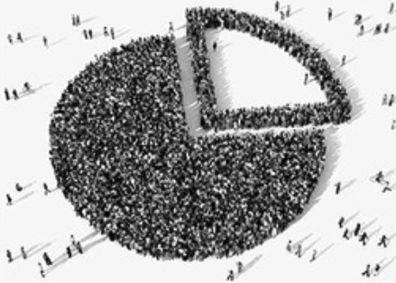

# Probability and Nonprobability Sampling

- Probability: participants are randomly selected and a sampling frame is often used.
- Nonprobability: participants are often not randomly selected and a sampling frame may not be available.
- Randomization for sampling means everyone in the population has an equal chance of participating in the study.
- It is common for qualitative studies to use nonprobability sampling types and for quantitative studies to use probability sampling types.
- Probability sampling often results in a larger sample size while nonprobability sampling results in a smaller sample size.

# Types of Nonprobability Sampling

> Nonprobability sampling includes various techniques that do not include an equal change of participation. They often involve populations that are difficult to reach or where a sampling frame does not exist.

## Convenience Sampling

- Convenience sampling: technique that allows the researcher to select any participants who are available to participate in a study, even if they are not representative of a population.
- Their participation happens by availability and accident, so this is often also called accidental sampling.
- Pilot studies: initial inquiries that pave the way for larger studies.
  - Helps avoid badly conducted larger studies.
  - Cost-effective way to test aspects of a study.

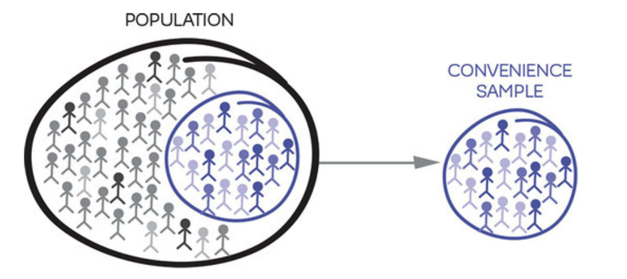

## Snowball Sampling

- Snowball sampling: technique in which participants are selected by word of mouth.
  - One or a few participants are willing to help find more participants.
  - May not be representative of the entire population because the researcher selects only participants who know each other.
- A researcher can start with convenience sampling and continue with snowball.
- A researcher should try to introduce as much participant variety as possible by encouraging participants to recommend people with specific characteristics to participate.

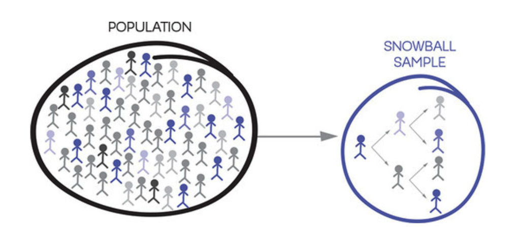

## Purposive Sampling

- Purposive sampling: technique that allows the researcher to select participants of interest for the study; also called judgmental sampling.
- Homogenous sampling: type of purposive sampling technique in which participants are chosen based on a trait of characteristic of interest.
  - Each participant must have the specific characteristic the researcher is looking for.
- Deviant case sampling: focuses on unusual or very specific cases.
- Purposive sampling allows a researcher to pick participants according to the characteristic under the study, but that means the results of the study cannot be generalized to the greater population and offer low external validity.

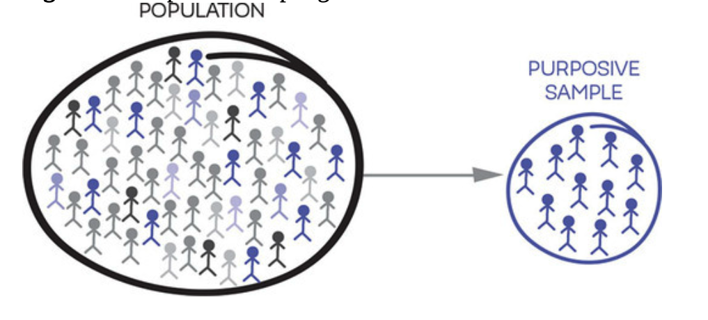

## Quota Sampling

- Quota sampling: technique that compares different groups within the population of interest; found in both qualitative and quantitative designs.
  - The researcher needs a sample of predetermined quota or proportions.
- Proportional quota sampling: the sample’s representation of the same proportion as it exists in the entire population of interest.
- Non-proportional quota sampling: uses a different quota from the one found in the population of interest because the study’s aim is to compare two or more different groups of interest.

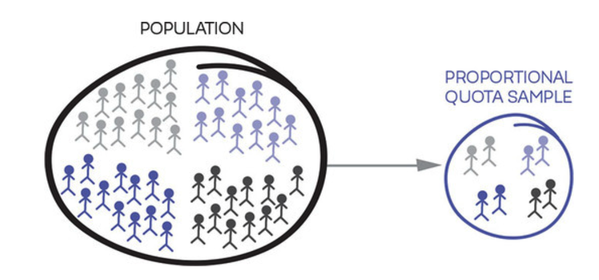

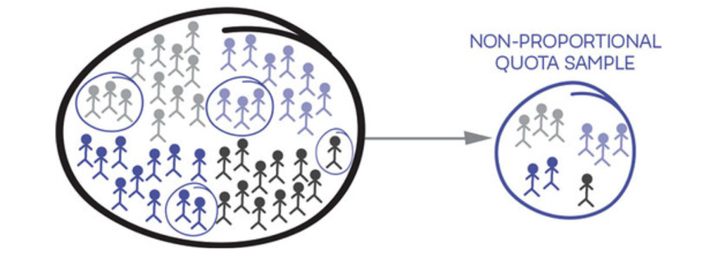

# Types of Probability Sampling

> All types of probability sampling use randomization, but they vary in the methodology used to choose participants, which depends on the aim of the study.

## Simple Random Sampling

- Simple random sampling: sampling procedure that relies on complete randomization without any specific boundaries.
- Conducted in one step using techniques such as random number generation.
- Every member has an equal chance of participating and it ensures representation of the population.
- It requires a complete list of the population from which the sample is drawn.

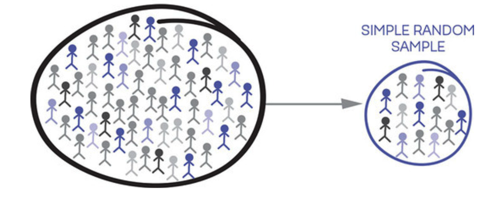

## Systematic Random Sampling

- Systematic random sampling: same technique as simple random sampling but has a level of organization embedded in it.
- A systematic way of randomly selecting participants from a sampling frame.
- Operates under the assumption that participants are randomly order in a sampling frame so everyone in the list has the same chance of participating in the study.